# Data preparation

Natasa Mortvanski

Universitat Pompeu Fabra  
natasa.mortvanski01@estudiant.upf.edu

2023-05-16

This document contains the code for data preparation (loading different alpha metrics, filtering of the samples and columns of interest) of American Gut Project data that is going to be used as healthy control in this Master thesis, as well as data from various studies of different pathological conditions supposedly affecting gut microbiome alpha diversity.

# Healthy data preprocessing

Loading necessary libraries:

```r
library(dplyr)
```

```r
#install.packages('purrr')
library(purrr)
library(tibble)
library(ggplot2)
library(stringr)
library(RColorBrewer)
library(gridExtra)
library(grid)
#install.packages("here")
library(here)
library(flextable)
label_fun <- function(x){
  if (x == "shannon_entropy"){y <- "Shannon entropy"} else if (x =="chao1"){y <- "Chao1"} else if (x == "menhinick"){y <- "Menhinick"} else if (x == "margalef"){y <- "Margalef"} else if (x == "fisher_alpha"){y <- "Fisher alpha"} else if (x == "simpson"){y <- "Simpson"} else if (x == "gini_index"){y <- "Gini index"} else if (x == "strong"){y <- "Strong dominance"} else if (x == "pielou_evenness"){y <- "Pielou evenness"} else if (x == "faith_pd"){y <- "Faith PD"}
  return(y)
}
```

### About dataset:

As a source of samples for healthy control we chose American Gut Project study. Data and metadata are available on Qiita platform:

1. Subset of the American Gut Project dataset (healthy dataset) -> [dataset link](https://qiita.ucsd.edu/study/description/10317)

Loading the metadata file for AGP study samples:

```r
AGP_metadata <- read.delim(here("00_raw_data/01_AGP_data", "10317_20221012-092710.txt.gz"))

nrow(AGP_metadata)
```

```
## [1] 37867
```

```r
length(AGP_metadata)
```

```
## [1] 738
```

Loading tables containing different alpha diversity metrics:

```r
# shannon_AGP <- read.delim(here("00_raw_data/01_AGP_data", "shannon_AGP_all.tsv.gz"))
# chao1_AGP <- read.delim(here("00_raw_data/01_AGP_data", "chao1_AGP_all.tsv.gz"))
# menhinick_AGP <- read.delim(here("00_raw_data/01_AGP_data", "menhinick_AGP_all.tsv.gz"))
# margalef_AGP <- read.delim(here("00_raw_data/01_AGP_data", "margalef_AGP_all.tsv.gz"))
# simpson_AGP <- read.delim(here("00_raw_data/01_AGP_data", "simpson_AGP_all.tsv.gz"))
# fisher_AGP <- read.delim(here("00_raw_data/01_AGP_data", "fisher_AGP_all.tsv.gz"))
# gini_AGP <- read.delim(here("00_raw_data/01_AGP_data", "gini_AGP_all.tsv.gz"))
# strong_AGP <- read.delim(here("00_raw_data/01_AGP_data", "strong_AGP_all.tsv.gz"))
# faith_AGP <- read.delim(here("00_raw_data/01_AGP_data", "faith_AGP_all.tsv.gz"))
# pielou_AGP <- read.delim(here("00_raw_data/01_AGP_data", "pielou_AGP_all.tsv.gz"))


shannon_AGP <- read.delim(here("00_raw_data/01_AGP_data", "shannon_AGP.tsv.gz"))
chao1_AGP <- read.delim(here("00_raw_data/01_AGP_data", "chao1_AGP.tsv.gz"))
menhinick_AGP <- read.delim(here("00_raw_data/01_AGP_data", "menhinick_AGP.tsv.gz"))
margalef_AGP <- read.delim(here("00_raw_data/01_AGP_data", "margalef_AGP.tsv.gz"))
simpson_AGP <- read.delim(here("00_raw_data/01_AGP_data", "simpson_AGP.tsv.gz"))
fisher_AGP <- read.delim(here("00_raw_data/01_AGP_data", "fisher_AGP.tsv.gz"))
gini_AGP <- read.delim(here("00_raw_data/01_AGP_data", "gini_AGP.tsv.gz"))
strong_AGP <- read.delim(here("00_raw_data/01_AGP_data", "strong_AGP.tsv.gz"))
faith_AGP <- read.delim(here("00_raw_data/01_AGP_data", "faith_AGP.tsv.gz"))
pielou_AGP <- read.delim(here("00_raw_data/01_AGP_data", "pielou_AGP.tsv.gz"))

# Merge alpha diversity data frames

names(faith_AGP)[names(faith_AGP) == 'X.SampleID'] <- 'X'
all_alpha <- list(shannon_AGP, chao1_AGP, menhinick_AGP, margalef_AGP, fisher_AGP, gini_AGP, strong_AGP, simpson_AGP, faith_AGP, pielou_AGP)
all_alpha <- all_alpha %>% reduce(inner_join, by="X")
names(all_alpha)[names(all_alpha) == 'X'] <- 'sample_id'


nrow(all_alpha)
```

```
## [1] 10064
```

Totall number of samples in this dataset is 10064.

Now lets combine alpha metrics and metadata in the same dataframe (`AGP`):

```r
# Merge all_alpha and AGP_metadata
AGP <- all_alpha %>% left_join(AGP_metadata, by=c('sample_id' = 'sample_name'))
AGP <- replace(AGP, is.na(AGP), "")


nrow(AGP)
```

```
## [1] 10064
```

We are left with 10064 samples for which alpha metrics were calculated.

Let’s define vector of names of the alpha diversity metrics that are going to be analysed:

```r
metric <- c("chao1", "margalef", "menhinick", "fisher_alpha", "faith_pd", "gini_index", "strong", "pielou_evenness", "shannon_entropy", "simpson")
```

Lets filter out samples that are truly healthy:

```r
# Filter samples by age (only adult samples)
AGP_healthy_subset <- AGP %>%
  filter(age_cat== "20s" |
         age_cat== "30s" |
         age_cat== "40s" |
         age_cat== "50s" |
         age_cat== "60s")

# Filter out stool and feces samples
AGP_healthy_subset <- AGP_healthy_subset %>%
  filter(sample_type=="feces" |
         sample_type=="Stool")
```

Check whether BMI category affects alpha diversity:

```r
for (i in 1:nrow(AGP_healthy_subset)){
  if (AGP_healthy_subset$host_body_mass_index[i] < 25){
    AGP_healthy_subset$BMI_cat[i] <- "normal"
  } else {
    AGP_healthy_subset$BMI_cat[i] <- "obese"
  }
}

table(AGP_healthy_subset$BMI_cat)
```

```
##
## normal  obese
##   3898   2946
```

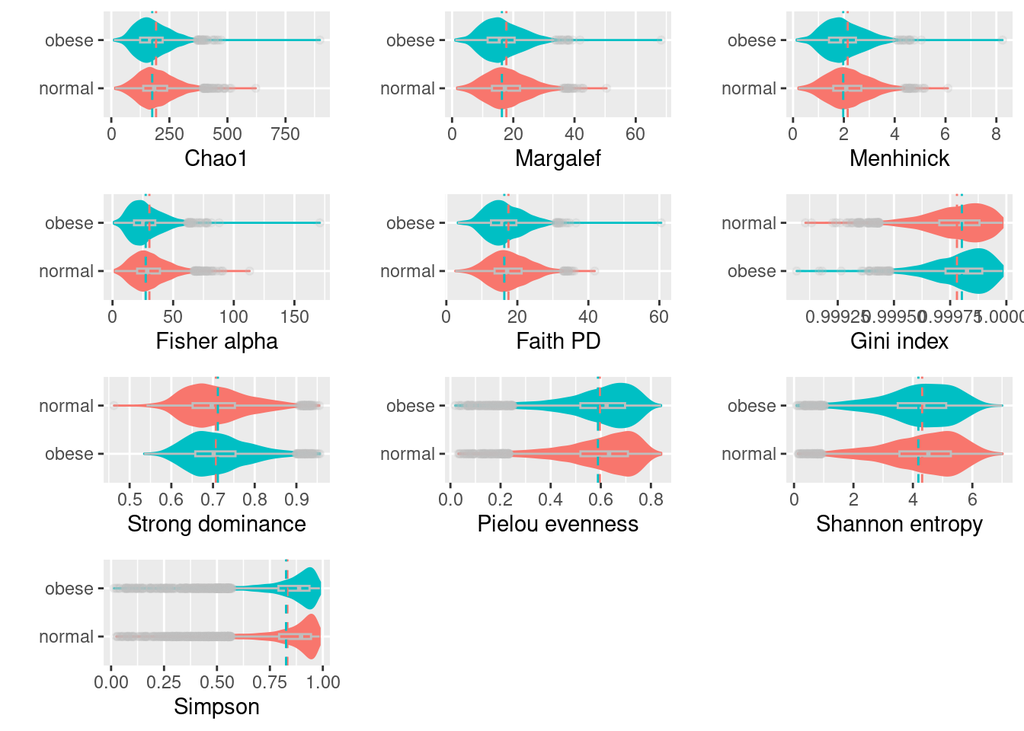

```r
violin <- vector('list', length(metric))

for (i in 1:length(metric)){
  mean_line <- AGP_healthy_subset %>% dplyr::group_by(BMI_cat) %>% dplyr::summarise(grp_mean=mean(.data[[metric[i]]]))
  plot_data <- AGP_healthy_subset %>% dplyr::group_by(BMI_cat) %>% dplyr::mutate(m = mean(.data[[metric[i]]]))

  violin[[i]] <- plot_data %>% ggplot(aes(x = .data[[metric[i]]], y = reorder(BMI_cat, -m), color = BMI_cat, fill = BMI_cat)) +
    geom_violin()+
    geom_boxplot(width=0.1, color="grey", alpha=0.2) +
    geom_vline(data = mean_line, aes(xintercept = grp_mean, color = BMI_cat), linetype = "dashed")+
    xlab(label_fun(metric[i])) +
    ylab("")+
    theme(legend.position="none")
}

grid.arrange(violin[[1]], violin[[2]], violin[[3]], violin[[4]], violin[[5]], violin[[6]], violin[[7]], violin[[8]], violin[[9]], violin[[10]], ncol=3)
```

```r
test <- list()

for (i in 1:length(metric)){
  test[[i]] <- pairwise.wilcox.test(AGP_healthy_subset[[metric[i]]], AGP_healthy_subset$BMI_cat, p.adjust.method="none") %>%
  broom::tidy() %>% add_column(parameter = metric[i], .before='group1')
  test[[i]]$p.value <- round(test[[i]]$p.value, digits = 5)
}

tests <- do.call(what = rbind, args = test)

tests <- tests %>%
  add_column(p.adjusted = round(p.adjust(tests$p.value, "fdr"), digits=5), .after='p.value') %>%
  arrange(p.value, parameter)  %>%
  flextable() %>%
  bold(~ p.value < 0.05, 4) %>%
  bold(~ p.adjusted < 0.05, 5) %>%
  add_header_lines(values = "Results of the Mann-Whitney-Wilcoxon test for...")

tests
```

| Results of the Mann-Whitney-Wilcoxon test for... parameter | Results of the Mann-Whitney-Wilcoxon test for... group1 | Results of the Mann-Whitney-Wilcoxon test for... group2 | Results of the Mann-Whitney-Wilcoxon test for... p.value | Results of the Mann-Whitney-Wilcoxon test for... p.adjusted |
| --- | --- | --- | --- | --- |
| chao1 | obese | normal | 0.00000 | 0.00000 |
| faith_pd | obese | normal | 0.00000 | 0.00000 |
| fisher_alpha | obese | normal | 0.00000 | 0.00000 |
| gini_index | obese | normal | 0.00000 | 0.00000 |
| margalef | obese | normal | 0.00000 | 0.00000 |
| menhinick | obese | normal | 0.00000 | 0.00000 |
| shannon_entropy | obese | normal | 0.00000 | 0.00000 |
| simpson | obese | normal | 0.00176 | 0.00220 |
| pielou_evenness | obese | normal | 0.00557 | 0.00581 |
| strong | obese | normal | 0.00581 | 0.00581 |

There is signifficant difference between obese and normal samples. It is necessary to filter out obese samples.

```r
#Keep only samples with normal BMI
AGP_healthy_subset <- AGP_healthy_subset %>%
  filter(host_body_mass_index > 18.5 &
         host_body_mass_index < 25)

# Filtering criteria No. 1
## Other solution is to apply only filters used in original AGP study:
AGP_healthy_subset_1 <- AGP_healthy_subset %>%
  filter(antibiotic_history=="I have not taken antibiotics in the past year." &
         diabetes=="I do not have this condition" &
         ibd=="I do not have this condition")

# Filtering criteria No. 2
## Filter out samples with reported IBD, IBS and Cdiff + no antibiotics
AGP_healthy_subset_2 <- AGP_healthy_subset %>%
  filter(antibiotic_history=="I have not taken antibiotics in the past year." &
         ibd=="I do not have this condition" &
         ibs=="I do not have this condition" &
         cdiff=="I do not have this condition")

# Filtering criteria No. 3
## Include only samples that have reported not having any of the following diseases
AGP_healthy_subset_3 <- AGP_healthy_subset %>%
  filter(antibiotic_history=="I have not taken antibiotics in the past year." &
         diabetes=="I do not have this condition" &
         ibd=="I do not have this condition" &
         ibs=="I do not have this condition" &
         cdiff=="I do not have this condition" &
         cancer=="I do not have this condition" &
         mental_illness=="No" &
         mental_illness_type_substance_abuse=="false" &
         mental_illness_type_depression=="false" &
         asd=="I do not have this condition" &
         alzheimers=="I do not have this condition" &
         add_adhd=="I do not have this condition" &
         epilepsy_or_seizure_disorder=="I do not have this condition" &
         sibo=="I do not have this condition" &   # small intestinal bacterial overgrowth
         pku =="I do not have this condition" &   # phenylketonuria
         thyroid=="I do not have this condition" &
         kidney_disease=="I do not have this condition" &
         clinical_condition=="I do not have this condition" &
         acid_reflux=="I do not have this condition" &
         autoimmune=="I do not have this condition" &
         cardiovascular_disease=="I do not have this condition" &
         lung_disease =="I do not have this condition" &
         liver_disease =="I do not have this condition")

# Number of samples after filtering only by criteria reported by AGP paper
nrow(AGP_healthy_subset_1)  #2292
```

```
## [1] 2253
```

```r
# Number of samples without IBD, IBS, Cdiff and no antibiotic use
nrow(AGP_healthy_subset_2)  #1494
```

```
## [1] 1471
```

```r
# Number of samples without any reported clinical condition
nrow(AGP_healthy_subset_3)  #600
```

```
## [1] 598
```

First subset of data filtered only by criteria from AGP paper contains 2253 samples. Second subset of data filtered by criteria from paper with additionally filtered out IBS and Cdiff positive samples contain 1471 samples. Finally, the third subset that consists of samples with none reported diseases contains 598 samples.

Lets see if there is a difference in values of alpha diversity metrics in different subsets:

```r
# make tables of summaries of all 4 subsets of AGP data
tabs <- list()
subsets <- list(AGP_healthy_subset, AGP_healthy_subset_1, AGP_healthy_subset_2, AGP_healthy_subset_3)

for(x in 1:length(subsets)){
tabs[[x]] <- subsets[[x]] %>%
  summarise(shannon_entropy,
            chao1,
            menhinick,
            margalef,
            simpson,
            pielou_evenness,
            #inverse_simpson,
            fisher_alpha,
            gini_index,
            strong,
            faith_pd) %>%
  broom::tidy()
}
# Extract minimums, means and maximums of each metric and combine them in new tables
cols <- c("column", "mean", "min", "max")
metric <- c("shannon_entropy", "chao1", "menhinick", "margalef", "fisher_alpha", "simpson", "gini_index", "strong", "pielou_evenness", "faith_pd" )
alpha_tables <- list()

for (i in 1:length(metric)){
  alpha_tables[[i]] <- tibble()
  for (x in tabs){
    alpha_tables[[i]] <- bind_rows(alpha_tables[[i]], filter(x, column == metric[[i]]))
  }
  alpha_tables[[i]] <- alpha_tables[[i]][, names(alpha_tables[[i]]) %in% cols]
  alpha_tables[[i]] <- alpha_tables[[i]] %>% add_column(subsample = c("AGP fecal samples of participants aged 20-69", "healthy AGP participants without any reported disease", "healthy AGP participants (AGP paper criteria)", "healthy AGP participants (no IBD, IBS, Cdiff + no antibiotics)"), .before = "column")
}

all_alpha_tables<- tibble()
for(x in 1:length(alpha_tables)){
  all_alpha_tables <- bind_rows(all_alpha_tables, alpha_tables[[x]])
}
```

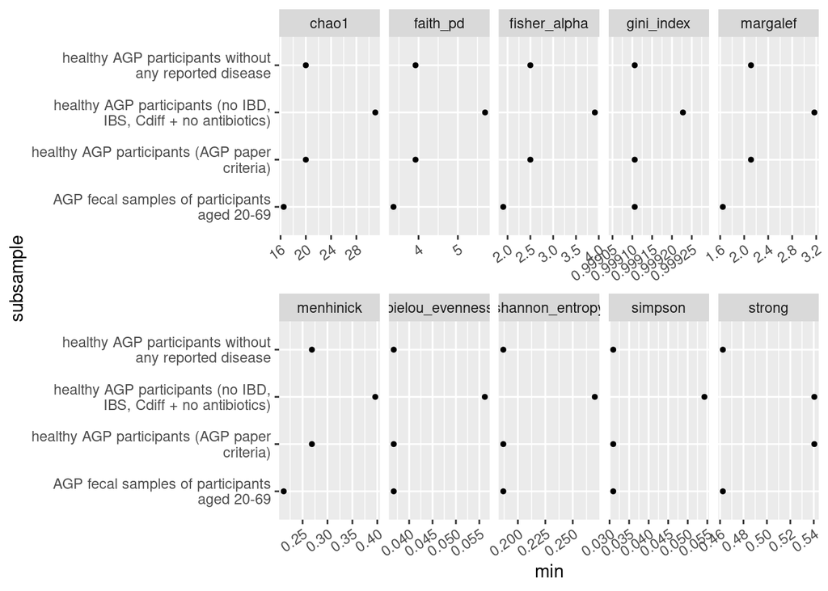

```r
# Plot values of min, mean and max for each subset of AGP data
all_alpha_tables %>%
  ggplot(aes(x= min, y=subsample)) +
  geom_dotplot(binaxis='y', stackdir='center') +
  theme(axis.text.x = element_text(angle = 35, vjust = 1, hjust=1)) +
  scale_y_discrete(labels = function(x) str_wrap(x, width = 35))+
  facet_wrap(column ~ ., scales = "free_x", ncol=5)
```

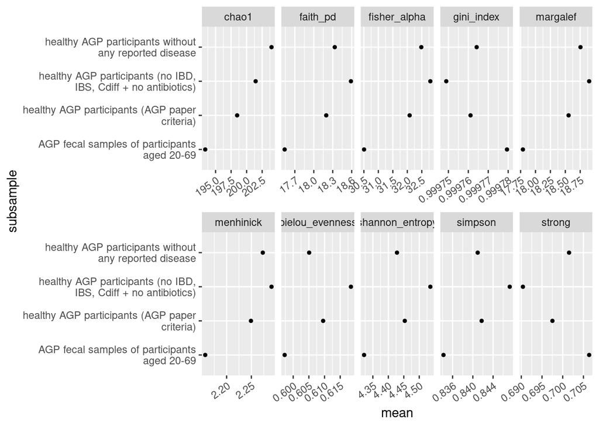

```r
all_alpha_tables %>%
  ggplot(aes(x= mean, y=subsample)) +
  geom_dotplot(binaxis='y', stackdir='center') +
  theme(axis.text.x = element_text(angle = 35, vjust = 1, hjust=1)) +
  scale_y_discrete(labels = function(x) str_wrap(x, width = 35))+
  facet_wrap(column ~ ., scales = "free_x", ncol=5)
```

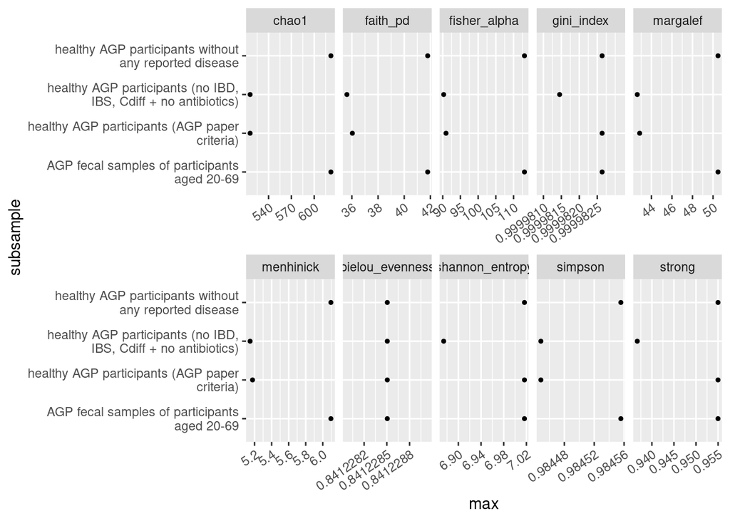

```r
all_alpha_tables %>%
  ggplot(aes(x= max, y=subsample)) +
  geom_dotplot(binaxis='y', stackdir='center') +
  theme(axis.text.x = element_text(angle = 35, vjust = 1, hjust=1)) +
  scale_y_discrete(labels = function(x) str_wrap(x, width = 35))+
  facet_wrap(column ~ ., scales = "free_x", ncol=5)
```

Lets explore how distributions of different metrics change in different subsets:

Generate a vector of 10 random colors for histograms:

```r
qual_col_pals <- brewer.pal.info[brewer.pal.info$category == 'qual',]
colors <- unlist(mapply(brewer.pal, qual_col_pals$maxcolors, rownames(qual_col_pals)))
```

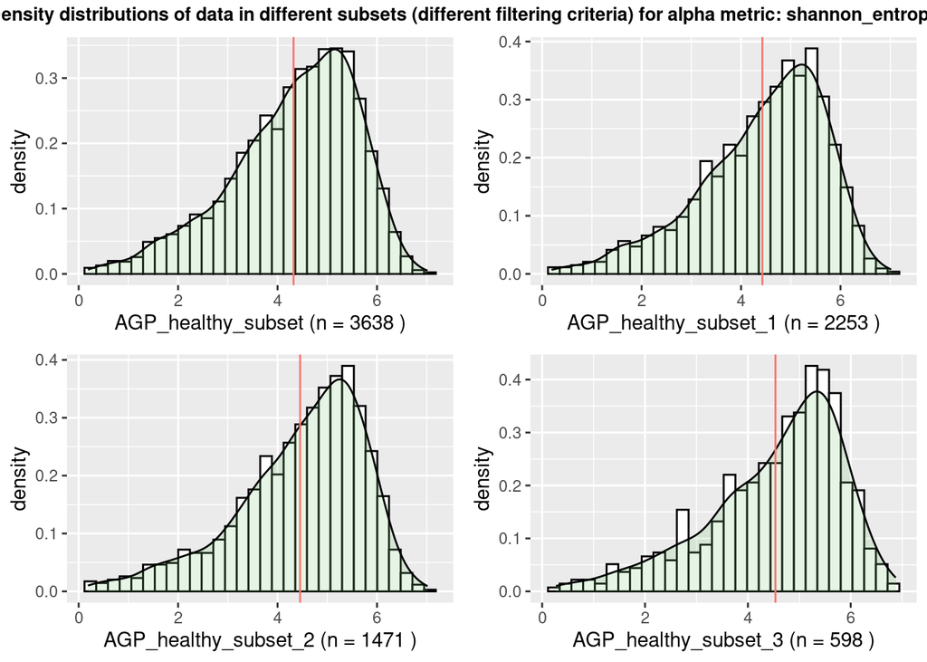

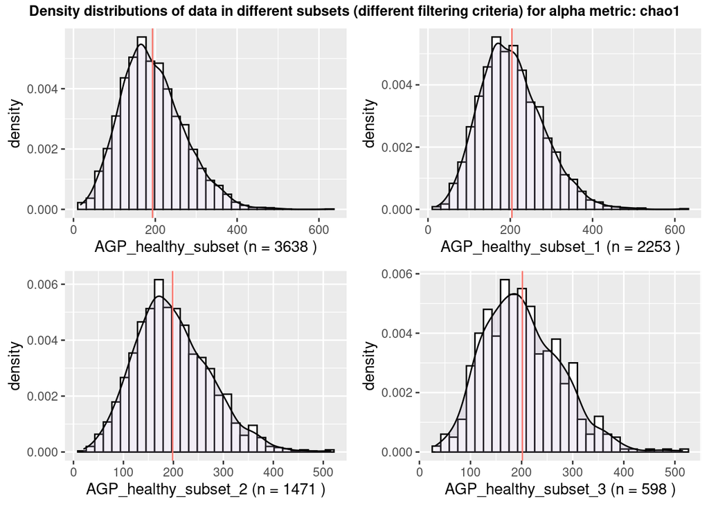

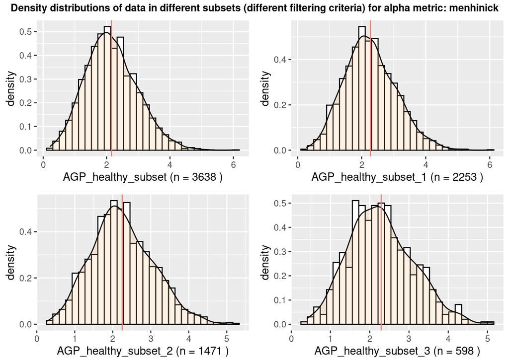

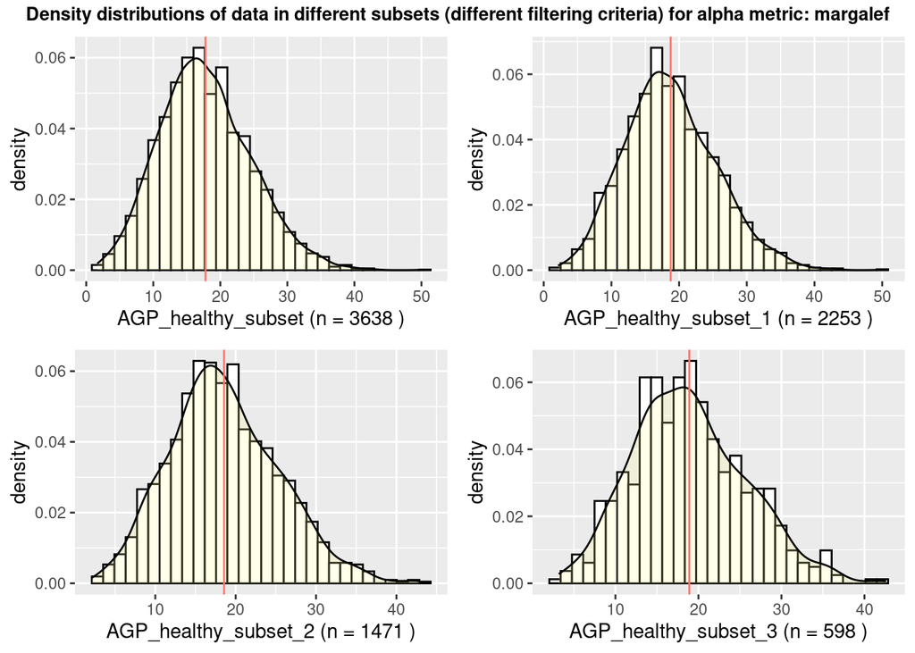

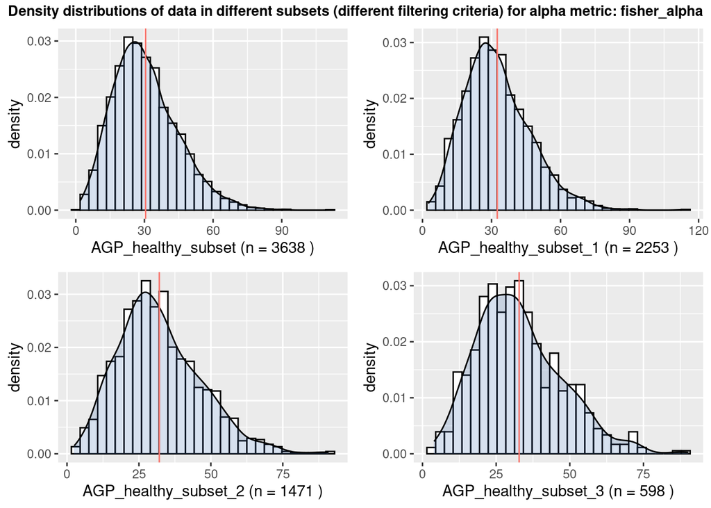

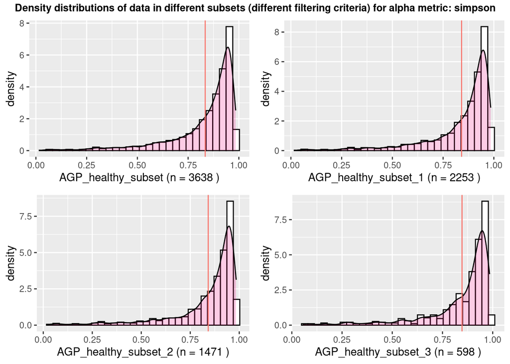

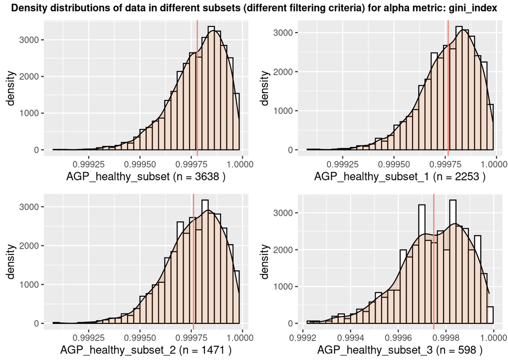

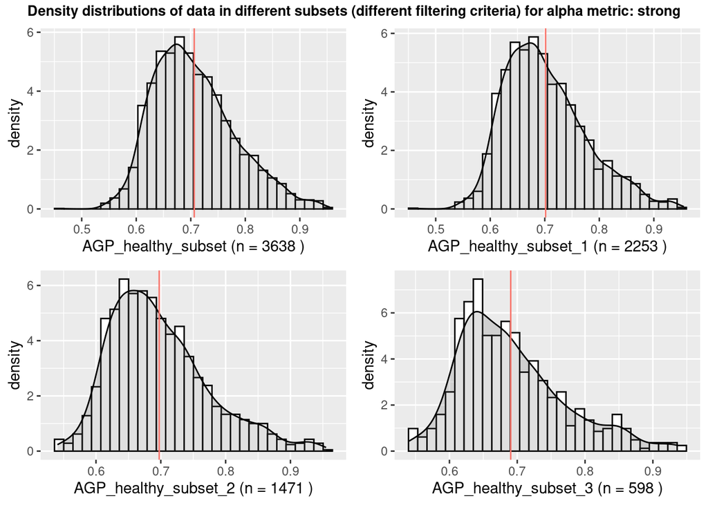

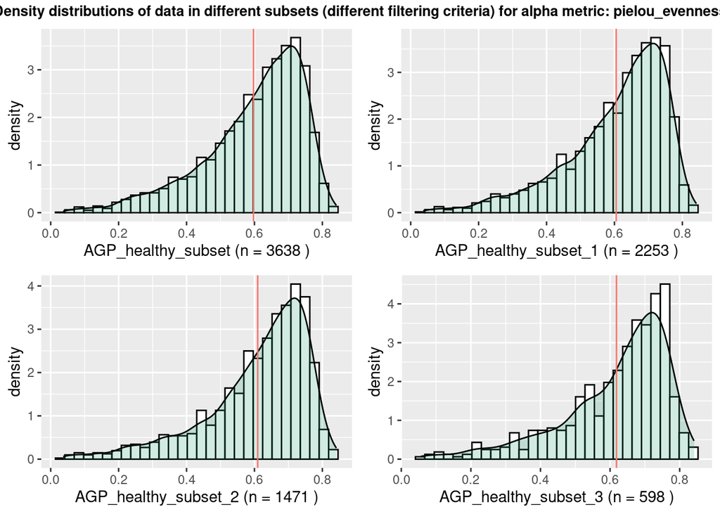

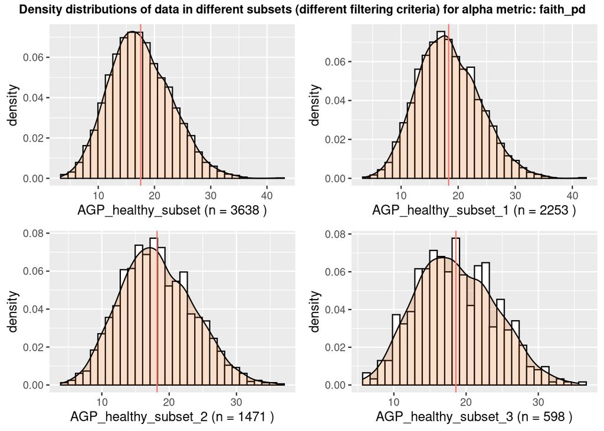

```r
subset_list <- list(AGP_healthy_subset, AGP_healthy_subset_1, AGP_healthy_subset_2, AGP_healthy_subset_3)
subset_names <- c("AGP_healthy_subset", "AGP_healthy_subset_1", "AGP_healthy_subset_2", "AGP_healthy_subset_3")
subset_list <- setNames(subset_list, subset_names)

histo <- vector('list', length(subset_list)*length(metric))

for (i in 1:length(metric)){
  for (j in 1:length(subset_list)){
    histo[[i]][[j]] <- subset_list[[j]] %>% ggplot(aes(x = .data[[metric[i]]])) +
      geom_histogram(aes(y=..density..), colour="black", fill="white", bins=30)+
      geom_density(alpha=.2, fill=colors[i]) +
      geom_vline(aes(xintercept = mean(.data[[metric[i]]]), colour = "red", linetype = "dashed"))+
      xlab(label = paste(names(subset_list[j]),"(n =", nrow(subset_list[[j]]), ")", sep=' ')) +
      ylab(label ="density")+
      theme(legend.position="none")
  }
}

plot_list <- list()
for (i in 1:length(metric)){
  plot_list[[i]] <- list()
  for (j in 1:length(subset_list)){
    plot_list[[i]][[j]] <- histo[[i]][[j]]
  }
}


for (i in 1:length(metric)){
  grid.arrange(grobs = plot_list[[i]], ncol=2, top = textGrob(paste ("Density distributions of data in different subsets (different filtering criteria) for alpha metric:", metric[i], sep =" "), gp=gpar(fontsize=10,font=2)))
}
```

For now lets use the subset of healthy samples that only excludes IBD, IBS, Cdiff and antibiotic use (since these are the conditions that will be our disease group in further analysis):

```r
AGP_healthy_subset <- AGP_healthy_subset_2

nrow(AGP_healthy_subset)
```

```
## [1] 1471
```

There is 1471 healthy samples.

One of the things we are interested in is the nutrition of study participants. AGP supposedly incorporates data from Vioscreen questionaire about nutrition habits. Let’s examine those columns:

```r
# Examine Vioscreen data columns
cols <- grep("^vioscreen.?", names(AGP_healthy_subset), value=T)

# Show unique values in each of the vioscreen columns
#lapply(AGP_healthy_subset[,cols], unique)
```

Vioscreen columns are highly redundand (empty). Furthermore, only available values for vioscreen columns are: “” and “not applicable”. We can delete vioscreen columns from the table AGP_healthy_subset because they are not informative:

```r
# Delete vioscreen columns
AGP_healthy_subset <- AGP_healthy_subset[, !names(AGP_healthy_subset) %in% cols]
```

Delete columns that are not informative enough, for example mostly empty, mostly consisting of ‘Unspecified’ answer or uniform (only have one category, so useless for comparisons):

```r
# Delete almost empty columns (missing more than 90% of the samples)
empty_columns <- colSums(is.na(AGP_healthy_subset) | AGP_healthy_subset == "") > nrow(AGP_healthy_subset)*0.9
AGP_healthy_subset <- AGP_healthy_subset[, !names(AGP_healthy_subset) %in% empty_columns]

# Delete columns that have more than 80% Uncpecified answers
unspec_columns <- colSums(AGP_healthy_subset == "Unspecified" | AGP_healthy_subset == "") > nrow(AGP_healthy_subset)*0.8
AGP_healthy_subset <- AGP_healthy_subset[, !unspec_columns]

#Delete columns with uniform values (all values are the same)
uniform_columns <- vapply(AGP_healthy_subset, function(x) length(unique(x)) == 1, logical(1L))
AGP_healthy_subset <- AGP_healthy_subset[, !uniform_columns]
```

Furthermore, we are not interested in examining effects of Covid or surfing on gut microbiome so we are going to delete these columns:

```r
# Delete covid related columns
cols <- grep("^covid?", names(AGP_healthy_subset), value=T)
AGP_healthy_subset <- AGP_healthy_subset[, !names(AGP_healthy_subset) %in% cols]

# Delete columns related to surfing data
cols <- grep("^surf_.?", names(AGP_healthy_subset), value=T)
AGP_healthy_subset <- AGP_healthy_subset[, !names(AGP_healthy_subset) %in% cols]
```

Other redundand columns:

- host_age_units - in years for all samples
- host_age_normalized_years is the same as host_age,
- host_subject_id and anonymized_name - we already have sample identifiers
- (sample_name), we don’t need subject ID since we don’t need to identify subjects
- roommates_in_study - irrelevant since we can’t identify them,
- toilet_water_access - irrelevant
- collection_timestamp - irrelevant

```r
# Delete columns
cols <- c('host_age_units', 'host_age_normalized_years', 'host_subject_id', 'roommates_in_study', 'toilet_water_access', 'anonymized_name', 'collection_timestamp')
AGP_healthy_subset <- AGP_healthy_subset[, !names(AGP_healthy_subset) %in% cols]

ncol(AGP_healthy_subset)
```

```
## [1] 221
```

```r
#colnames(AGP_healthy_subset)
```

We are left with 221 columns relating to participants’ nutrition habits, allergies, physical activity, cohabitation etc.

Check other columns of interest

```r
table(AGP_healthy_subset$sex)
```

```
##
## female   male  other
##    879    591      1
```

```r
# cathegories: female, male, other, unspecified

# Delete other and unspecified
AGP_healthy_subset <- AGP_healthy_subset %>%
  filter(sex=="female" | sex=="male")

# table(AGP_healthy_subset$bmi_cat)
# # cathegories: Normal, Unspecified
#
# # Delete Unspecified
# AGP_healthy_subset <- AGP_healthy_subset %>%
#   filter(bmi_cat !="Unspecified")
```

```r
nrow(AGP)
```

```
## [1] 10064
```

```r
nrow(AGP_healthy_subset)
```

```
## [1] 1470
```

```r
table(AGP_healthy_subset$bmi_cat)
```

```
##
##      Normal Unspecified
##        1465           5
```

Add condition:

```r
AGP_healthy_subset$condition <- 'healthy'
```

Export table into csv format:

```r
write.csv(AGP, gzfile(here("01_tidy_data", "AGP_all.csv.gz")), row.names=FALSE)
write.csv(AGP_healthy_subset, gzfile(here("01_tidy_data", "AGP_healthy.csv.gz")), row.names=FALSE)
```